# Results

Author

Torbjørn Ergon

Published

January 7, 2025

DETTE ER ET INTERNT ARBEIDSDOKUMENT - IKKE MENT FOR PUBLISERING (men skriver på engelsk av vane og for eventuelt gjenbruk)

SISTE OPPDATERING:

- Bruker nå bare det jeg før kalte “super wide priors” for ‘mu’.
- Har retta opp feil i data

OPPSUMMERING *FØR* SISTE ZOOM-MØTE (kopiert fra e-post):

- Gamma-modellen (den beste WAIC-modellen) hadde vi formulert på en litt innfløkt måte og vi hadde også gjort det litt feil. Jeg forsøkte å gjøre det på en mye enklere måte, men da fikk jeg problemer med særdeles dårlig mixing i mcmc-kjedene fra NIMBLE som jeg ikke fant ut av (jeg viste det til Daniel Turek som har laget NIMBLE, og som jeg kjenner godt – han syntes det var interessant, men fant heller ikke noen rask løsning). Long-story-short, jeg fant til slutt en slags reparameterisering av modellen (med en annen variance-mean relationship som lignet på den måten vi først gjorde det (bare riktig denne gangen)) som fungerte. All good.
- Jeg gjorde ‘posterior predictive checks’ på modellene. Disse viste at det er betydelig mer variasjon i y-matrisa (antallet sett av obs1, ob2 og begge for hvert site) enn det man skal forvente utfra modellen. For å hanskes med dette innførte jeg en random effekt på deteksjonssansynlighetene. Dette løste problemet, men ga naturligvis enda litt bredere konfidensintervaller (eller «credible intervals» for å være mer korrekt) – men ikke så mye som man kunne frykte. All good.
- Jeg har gjort noen sensitivitetsanalyser – bl.a. sett på betydningen av ulike priors og overlapp mellom priors og posteriors. Dette viste at det var urovekkende høy overlapp mellom prior og posterior for noen av parameterene. For noen av parameterene var dette forventet for vi har bruk priors som er noe informative – spesielt for deteksjonssannsynlighetene der vi har brukt informasjon fra flyvningene over inngjerdingene. For mu0 (median tetthet ved gjennomsnittlig avstand fra innmark) brukte vi også litt informative priors basert på enkle estimater av deteksjonssannsynlighet og antall hjort sett. Vi gjorde dette helt fra starten av for å beregne noen rimelige startverdier og for å få en raskere konvergens i mcmc-kjøringene. Jeg regna likevel med at vi satt priors såpass vide at de hadde liten innvirkning på resultatet – men det er dessverre ikke tilfelle; for m0 er overlap mellom prior og posterior mellom 60% (for områder med mest data) til 98% (!) for områder det det ikke er sett hjort i det hele tatt. Så for områdene der det ikke er sett hjort får vi altså posterior-fordelinger som er så å si helt lik priors, og for de andre områdene er overlappen også urovekkende stor (vi burde selvsagt ha sjekka dette tidligere). Jeg har sjekka med simulering at vi får smalere konfidensintervaller som er mye smalere med mye mer data, så jeg tror ikke det er noe iboende i modellen som gjør noen parametere uidentifiserbare

REFERAT FRA SISTE ZOOM-MØTE (kopiert fra e-post):

Her er noen oppsummeringspunkter – og noen tanker videre som vi kan huske på i skrivingen (kommenter gjerne):

## 1 Overview of raw data

Number of sites (focal images) per ‘sample-area-and-month’ (‘sam’):

```
      Haugen (April)       Haugen (March)          Raa (April)
                  24                   43                   24
         Raa (March) Søre Bjørkum (April) Søre Bjørkum (March)
                  35                   40                   87
  Sprakehaug (April)   Sprakehaug (March)
                  17                   31
```

Total area per sample-area-and-month (unit: hectare = % of 1 km$^2$)

```
      Haugen (April)       Haugen (March)          Raa (April)
           15.747583            28.074854             5.356925
         Raa (March) Søre Bjørkum (April) Søre Bjørkum (March)
           10.580784            23.404229            64.876724
  Sprakehaug (April)   Sprakehaug (March)
           10.198860            18.641124
```

Numbers of deer seen per ‘sample-area-and-month’ (‘sam’):

```
      Haugen (April)       Haugen (March)          Raa (April)
                  12                   14                    0
         Raa (March) Søre Bjørkum (April) Søre Bjørkum (March)
                   0                    4                   23
  Sprakehaug (April)   Sprakehaug (March)
                   0                    2
```

Frequency distribution of number of deer seen per site (focal image):

```r
table(nimbleData$data$Y)
```

```
  0   1   2   3   5   7
274  10  12   3   1   1
```

Variance divided by the mean is

```
[1] 2.717212
```

This is quite much higher than expected from a Poisson distribution (where var/mean = 1). Some of this will be explained by the fixed effects in the model (area-and-month and distance from the field), and the rest will be accounted for by the random effects. Seeing the high number of zeros, one could be tempted to try a model with zero-inflation, but I would find this model to be a a bit strange (would there be a lot of sites that never would have any deer?? I don’t think so…) - so I haven’t tried this.

Simple point estimate of detectability based on how many of those seen by obs1 is seen by obs2 and vice versa:

```r
colsumy <- apply(nimbleData$data$y, 3, sum, na.rm=TRUE)
p1hat <- colsumy[3]/(colsumy[2]+colsumy[3]) # = 0.70
p2hat <- colsumy[3]/(colsumy[1]+colsumy[3]) # = 0.90
(phat_simple <- 1 - (1-p1hat)*(1-p2hat))
```

```
     both
0.9763314
```

This is the probability that at least one of the two observers registered a given deer in the picture (obs1 has probability 0.7 and obs2 has probability 0.9).

Simple density estimates per ‘sam’ (unit = number of deer per hectare)

```r
(lambdahat <- (Y_per_sam/phat_simple)/area_per_sam)
```

```
      Haugen (April)       Haugen (March)          Raa (April)
           0.7804950            0.5107558            0.0000000
         Raa (March) Søre Bjørkum (April) Søre Bjørkum (March)
           0.0000000            0.1750525            0.3631129
  Sprakehaug (April)   Sprakehaug (March)
           0.0000000            0.1098906
```

The estimates per km$^2$ are 100 times this.

We can use the logarithms of these values to construct priors for ‘mu0’ (the log of median densities at mean distance from the field). The sam’s where there are zero observations pose a problem. We cannot say much in terms of a point estimate or a lower confidence/credible interval in these cases, but there is some information about the upper confidence/credible interval (i.e, we can get some idea about how high the densities can potentially be for these areas with zero counts). To use the same prior-structure as for the other sams I computed prior mean densities from mcmc-sampling with a simple Poisson-model as specified in the script ‘prior_zero_sites.r’

## 2 Checking convergence and WAIC models

```
 ** exponential_0 **
Number of runs: 1
Settings for each run:
  niter nburnin  nchain    thin
  2e+05   2e+04   3e+00   6e+00

Convergence diagnostics for all chains combined:
Error in chol.default(W) : the leading minor of order 13 is not positive

WIAC in each run: 122.8444
Mean WAIC: 122.8444

 ** lognormal_0 **
Number of runs: 1
Settings for each run:
  niter nburnin  nchain    thin
  2e+05   2e+04   3e+00   6e+00

Convergence diagnostics for all chains combined:
Potential scale reduction factors:

           Point est. Upper C.I.
Disc_New_Y       1.00       1.00
Disc_New_y       1.00       1.00
Disc_Y           1.00       1.00
Disc_y           1.01       1.02
eta1             1.01       1.02
eta2             1.00       1.01
mean_ds[1]       1.00       1.00
mean_ds[2]       1.00       1.00
mean_ds[3]       1.00       1.00
mean_ds[4]       1.00       1.00
mean_ds[5]       1.00       1.00
mean_ds[6]       1.00       1.00
mean_ds[7]       1.00       1.00
mean_ds[8]       1.00       1.00
mu0[1]           1.00       1.00
mu0[2]           1.00       1.00
mu0[3]           1.00       1.00
mu0[4]           1.00       1.00
```

[output cut: 299 more lines]

```
mu0[3]           1.00       1.00
mu0[4]           1.01       1.02
mu0[5]           1.00       1.00
mu0[6]           1.00       1.00
mu0[7]           1.01       1.02
mu0[8]           1.00       1.00
sigma            1.00       1.00
sigma_p          1.05       1.15

Multivariate psrf

1.05

WIAC in each run: 112.3725
Mean WAIC: 112.3725
```

| model | WAIC |
| --- | --- |
| exponential_0 | 122.8444 |
| lognormal_0 | 113.6804 |
| gamma_0 | 112.3192 |
| exponential_1 | 122.2770 |
| lognormal_1 | 113.6368 |
| gamma_1 | 112.4030 |
| exponential_2 | 121.4750 |
| lognormal_2 | 113.7912 |
| gamma_2 | 112.3725 |

There are some parameters that have problems with convergence in the exponential models now that I didn’t have when I used more restrictive parameters, I will have to look closer at that to see if it can be improved. However, since these models were far from having the lowest WAIC also when convergence was good (more restricted priors), I’m sure these model will not get the lowest WAIC even with good convergence - this can also be assessed from the differences in the WAIC values between the runs (each run has 3 chains).

## 3 Convergence diagnistics from the long run of the gamma_2 model

```
Potential scale reduction factors:

           Point est. Upper C.I.
Disc_New_Y       1.00       1.01
Disc_New_y       1.00       1.00
Disc_Y           1.00       1.01
Disc_y           1.00       1.01
beta[1]          1.00       1.00
beta[2]          1.00       1.00
eta1             1.01       1.05
eta2             1.02       1.06
mean_ds[1]       1.00       1.00
mean_ds[2]       1.00       1.00
mean_ds[3]       1.00       1.00
mean_ds[4]       1.01       1.01
mean_ds[5]       1.00       1.00
mean_ds[6]       1.00       1.00
mean_ds[7]       1.00       1.00
mean_ds[8]       1.00       1.00
mu0[1]           1.00       1.00
mu0[2]           1.00       1.00
mu0[3]           1.00       1.00
mu0[4]           1.01       1.02
mu0[5]           1.00       1.00
mu0[6]           1.00       1.00
mu0[7]           1.01       1.02
mu0[8]           1.00       1.00
sigma            1.00       1.00
sigma_p          1.05       1.15

Multivariate psrf

1.05
```

## 4 Posterior predictive checks of best model

Posterior predictive checks on initial models showed that we need random effects on detection probabilities to get acceptable fit (see summary in beginning of the document). I here only show the Bayesian p-value plots for the final best model.

### 4.1 Bayesian p-value based on Y

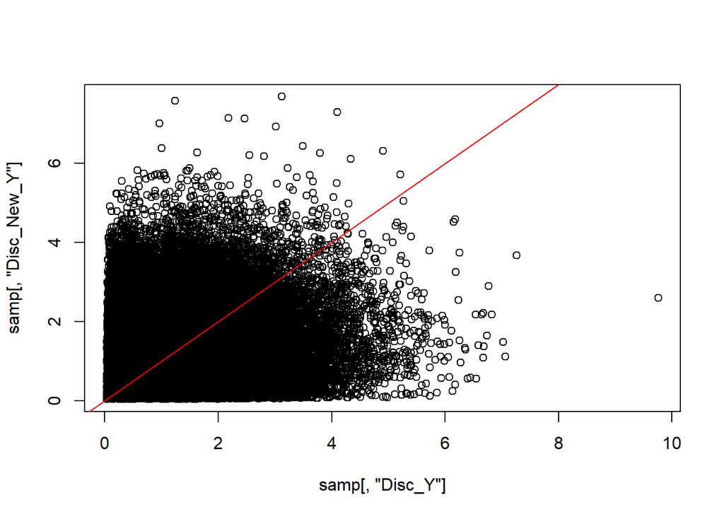

```
[1] 0.4978
```

### 4.2 Bayesian p-value based on y

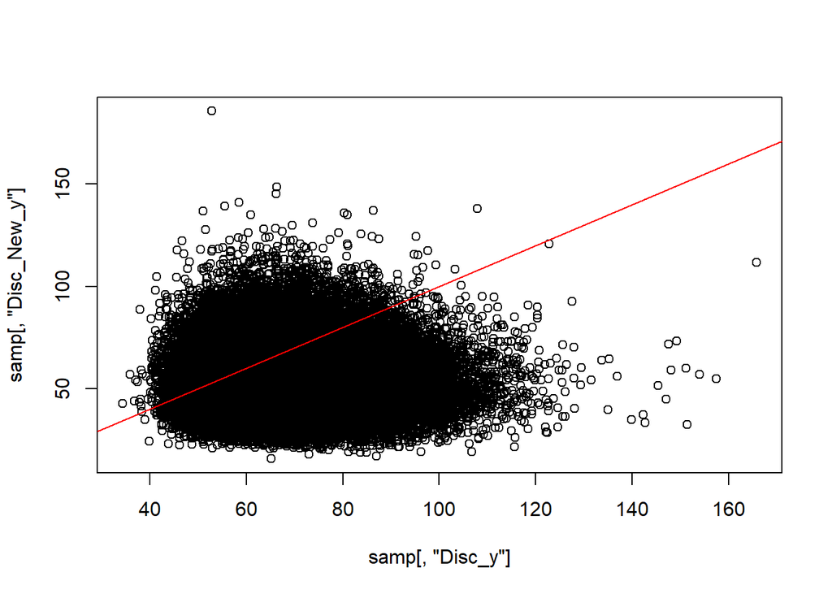

```
[1] 0.1933444
```

### 4.3 Conclusion

No indication of serious lack of fit.

## 5 Summary of best model

```
Iterations = 1:30000
Thinning interval = 1
Number of chains = 3
Sample size per chain = 30000

1. Empirical mean and standard deviation for each variable,
   plus standard error of the mean:

                 Mean       SD  Naive SE Time-series SE
beta[1]     9.325e-01 0.439774 1.466e-03      4.414e-03
beta[2]    -3.060e-01 0.272095 9.070e-04      2.708e-03
eta1        1.079e+00 0.253491 8.450e-04      8.405e-03
eta2        1.808e+00 0.277688 9.256e-04      1.006e-02
mean_ds[1]  7.907e-01 0.045026 1.501e-04      2.800e-04
mean_ds[2]  5.183e-01 0.028043 9.348e-05      1.990e-04
mean_ds[3]  7.633e-04 0.012422 4.141e-05      5.442e-05
mean_ds[4]  3.843e-04 0.006145 2.048e-05      2.581e-05
mean_ds[5]  1.783e-01 0.018482 6.161e-05      8.326e-05
mean_ds[6]  3.702e-01 0.016854 5.618e-05      1.584e-04
mean_ds[7]  3.900e-04 0.006275 2.092e-05      2.396e-05
mean_ds[8]  1.119e-01 0.016205 5.402e-05      6.798e-05
mu0[1]     -1.106e+00 0.730433 2.435e-03      3.038e-03
mu0[2]     -1.683e+00 0.555315 1.851e-03      2.872e-03
mu0[3]     -9.205e+00 5.744785 1.915e-02      1.748e-01
mu0[4]     -1.007e+01 5.978844 1.993e-02      2.365e-01
mu0[5]     -3.283e+00 0.816852 2.723e-03      5.289e-03
mu0[6]     -1.897e+00 0.556873 1.856e-03      4.096e-03
mu0[7]     -1.062e+01 5.703284 1.901e-02      1.435e-01
mu0[8]     -3.739e+00 1.050513 3.502e-03      7.095e-03
sigma       1.475e+00 0.106589 3.553e-04      2.001e-03
sigma_p     4.150e-01 0.130057 4.335e-04      7.140e-03

2. Quantiles for each variable:

               2.5%      25%     50%     75%   97.5%
beta[1]      0.1197   0.6340  0.9107  1.2095  1.8577
beta[2]     -0.8527  -0.4819 -0.3023 -0.1269  0.2228
eta1         0.5942   0.9038  1.0773  1.2508  1.5841
eta2         1.2701   1.6169  1.8092  1.9975  2.3513
mean_ds[1]   0.7620   0.7620  0.7620  0.8255  0.8890
mean_ds[2]   0.4987   0.4987  0.4987  0.5343  0.6055
mean_ds[3]   0.0000   0.0000  0.0000  0.0000  0.0000
mean_ds[4]   0.0000   0.0000  0.0000  0.0000  0.0000
mean_ds[5]   0.1709   0.1709  0.1709  0.1709  0.2136
mean_ds[6]   0.3545   0.3545  0.3699  0.3853  0.4162
mean_ds[7]   0.0000   0.0000  0.0000  0.0000  0.0000
mean_ds[8]   0.1073   0.1073  0.1073  0.1073  0.1609
mu0[1]      -2.4443  -1.5935 -1.1409 -0.6618  0.4391
mu0[2]      -2.7556  -2.0530 -1.6912 -1.3221 -0.5722
mu0[3]     -23.2634 -12.4514 -8.0056 -4.8528 -1.4291
mu0[4]     -24.6458 -13.2354 -8.8568 -5.6456 -2.2541
mu0[5]      -4.9505  -3.8089 -3.2604 -2.7358 -1.7333
mu0[6]      -2.9858  -2.2629 -1.9033 -1.5360 -0.7846
mu0[7]     -24.3959 -13.7919 -9.4837 -6.3022 -2.9712
mu0[8]      -5.9523  -4.3948 -3.6837 -3.0257 -1.8186
sigma        1.2614   1.4048  1.4767  1.5478  1.6780
sigma_p      0.1196   0.3243  0.4420  0.5249  0.5844
```

## 6 Predictions from the best model

### 6.1 Plot

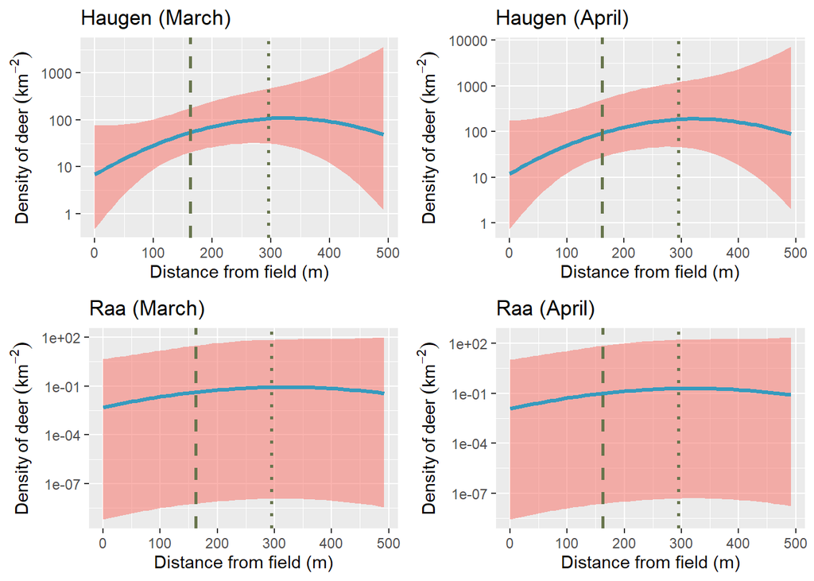

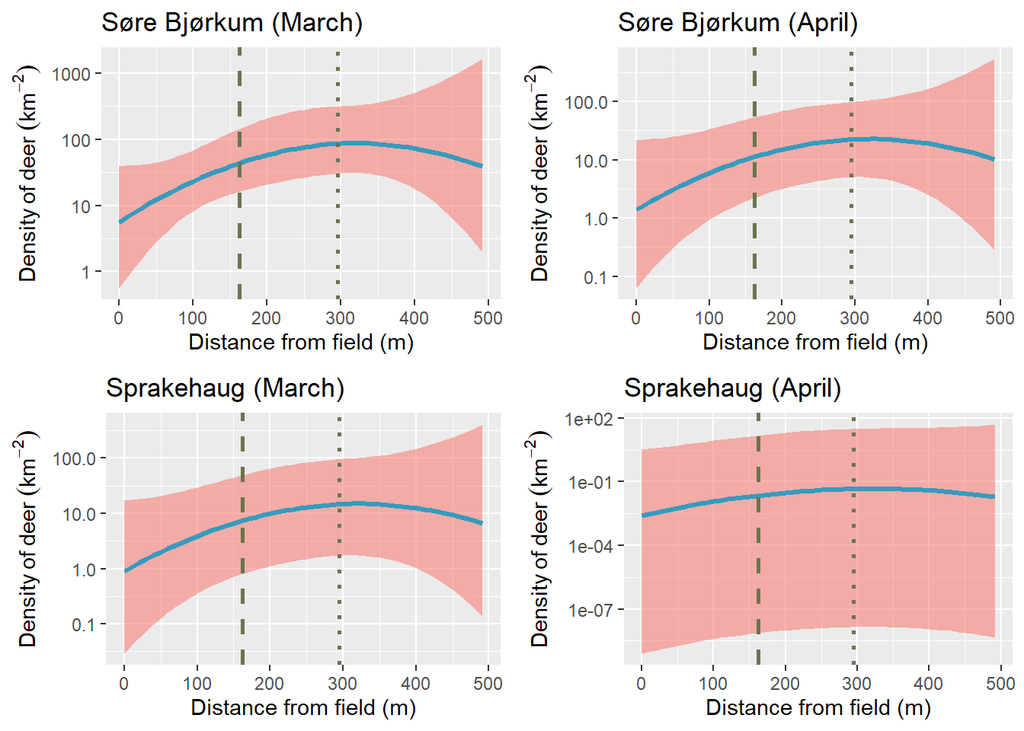

- Mean distance from the field (stippled line): 162 meters.
- Posterior median of distance at peak deer density (dotted line): 295 meters.

Posterior summary for distance at peak deer density:

```
     2.5%       50%     97.5%
-682.1395  295.2636 1249.5927
```

### 6.2 Table - Predictions at peak deer density (for table A3):

- Kommentar: Jeg har her brukt samme rekkefølge som i figuren (den rekkefølgen du har på plottene i manus), men table A3 har en annen rekkefølge. Jeg synes du skal bruke samme rekkefølge i figur og tabell. Kanskje du også skal forenkle å bare ta med posterior median, 2.5 percentil og 97.5 percentil - det er det jeg har gjort i plottet nå. (Denne tabellen (eller den under) bør kanskje heller være i hovedteksen og ikke i Appendix?)

Density units: number of deer per km$^2$.

x = distance from field

|  | SAM | x | mean | median | lwr | upr |
| --- | --- | --- | --- | --- | --- | --- |
| 2 | Haugen (March) | 295.26 | 142.50 | 106.70 | 31.36 | 465.76 |
| 1 | Haugen (April) | 295.26 | 305.99 | 184.81 | 45.69 | 1211.61 |
| 4 | Raa (March) | 295.26 | 8.44 | 0.08 | 0.00 | 69.65 |
| 3 | Raa (April) | 295.26 | 21.89 | 0.19 | 0.00 | 164.38 |
| 6 | Søre Bjørkum (March) | 295.26 | 107.72 | 86.19 | 30.46 | 315.42 |
| 5 | Søre Bjørkum (April) | 295.26 | 29.91 | 22.30 | 5.03 | 99.27 |
| 8 | Sprakehaug (March) | 295.26 | 23.30 | 14.64 | 1.72 | 96.18 |
| 7 | Sprakehaug (April) | 295.26 | 5.71 | 0.05 | 0.00 | 30.67 |

### 6.3 Table - Predictions at mean distance from the field:

|  | SAM | x | mean | median | lwr | upr |
| --- | --- | --- | --- | --- | --- | --- |
| 2 | Haugen (March) | 162.26 | 65.26 | 54.00 | 20.41 | 176.48 |
| 1 | Haugen (April) | 162.26 | 140.10 | 93.20 | 27.89 | 497.41 |
| 4 | Raa (March) | 162.26 | 3.66 | 0.04 | 0.00 | 31.65 |
| 3 | Raa (April) | 162.26 | 9.20 | 0.10 | 0.00 | 72.75 |
| 6 | Søre Bjørkum (March) | 162.26 | 52.76 | 43.63 | 16.26 | 143.46 |
| 5 | Søre Bjørkum (April) | 162.26 | 15.57 | 11.30 | 2.23 | 53.40 |
| 8 | Sprakehaug (March) | 162.26 | 12.02 | 7.41 | 0.81 | 49.22 |
| 7 | Sprakehaug (April) | 162.26 | 2.93 | 0.02 | 0.00 | 15.57 |

Konfidensintervallene blir jo her smallere. Jeg forelsår vi presenterer bare denne istedenfor.

## 7 Overlap with prior

Overlap between prior distribution and posterior distribution (multiply by 100 to get % overlap):

```
          par                  sam     overlap
1     beta[1]                 <NA> 0.347723539
2     beta[2]                 <NA> 0.260435425
3        eta1                 <NA> 0.060739380
4        eta2                 <NA> 0.063664071
5  mean_ds[1]       Haugen (April) 0.005896837
6  mean_ds[2]       Haugen (March) 0.003963524
7  mean_ds[3]          Raa (April) 0.000801655
8  mean_ds[4]          Raa (March) 0.000415309
9  mean_ds[5] Søre Bjørkum (April) 0.002010347
10 mean_ds[6] Søre Bjørkum (March) 0.003519493
11 mean_ds[7]   Sprakehaug (April) 0.000000000
12 mean_ds[8]   Sprakehaug (March) 0.000000000
13     mu0[1]       Haugen (April) 0.021419588
14     mu0[2]       Haugen (March) 0.001663075
15     mu0[3]          Raa (April) 0.000000000
16     mu0[4]          Raa (March) 0.000000000
17     mu0[5] Søre Bjørkum (April) 0.000000000
18     mu0[6] Søre Bjørkum (March) 0.000000000
19     mu0[7]   Sprakehaug (April) 0.000000000
20     mu0[8]   Sprakehaug (March) 0.000000000
21      sigma                 <NA> 0.000000000
22    sigma_p                 <NA> 0.000000000
```

## 8 Predictions from the constant gamma model

|  | SAM | mean | median | lwr | upr |
| --- | --- | --- | --- | --- | --- |
| 2 | Haugen (March) | 65.81 | 54.00 | 20.10 | 178.82 |
| 1 | Haugen (April) | 162.10 | 98.51 | 29.19 | 559.85 |
| 4 | Raa (March) | 1.37 | 0.02 | 0.00 | 12.24 |
| 3 | Raa (April) | 3.31 | 0.04 | 0.00 | 28.07 |
| 6 | Søre Bjørkum (March) | 41.40 | 37.84 | 18.21 | 85.90 |
| 5 | Søre Bjørkum (April) | 24.04 | 18.14 | 4.20 | 78.61 |
| 8 | Sprakehaug (March) | 16.42 | 10.70 | 1.32 | 63.98 |
| 7 | Sprakehaug (April) | 2.70 | 0.03 | 0.00 | 18.53 |

## 9 Some sensitivity assessment

### 9.1 Choice of radom distribution for $\lambda$

Predictions from each of the models at mean distance from field at Haugen in March:

```
          Model      mean   median      lwr       upr
1 exponential_0  53.05573 50.90557 26.95977  91.46535
2   lognormal_0 151.46376 81.22466 23.80980 561.64738
3       gamma_0  65.80514 53.99874 20.09585 178.82009
4 exponential_1  49.15948 47.20116 24.60848  85.37147
5   lognormal_1 174.18770 73.54328 21.44966 512.14349
6       gamma_1  63.06100 52.41132 19.92309 168.83099
7 exponential_2  49.44092 47.42910 24.56713  85.91383
8   lognormal_2 165.15533 76.91900 21.83476 597.09955
9       gamma_2  65.26422 53.99850 20.40609 176.47555
```

### 9.2 Influence of restrictive prior for $\sigma_p$

NB! This has not (yet) been updated with “superwide” priors and corrected data.

Summaries from a model where I increased the upper limit of the the random effects SD for detection log-odds from 0.59 to 5.

## 10 Proof of concept - Indentifiablity

NB! This has not (yet) been updated with “superwide” priors and corrected data.

To check that there are no inherent identifiability problems with the model, I fitted the model to simulated data; 8 areas with 500 sites. Parameters set to posterior mean of original fit. Same priors as original (IKKE “superwide” - bør oppdatere).

Predictions at peak density:

[output not shown]

Predictions at mean distance from field:

[output not shown]

One would perhaps expect higher precision (narrower credible intervals) when having 8 $\times$ 500 sites but the high variation in number of deer per sites contributes to much uncertainty, and since the average area of sites is just under 0.6 ha (0.6% of a km$^2$), the expected counts per km$^2$ is quite small.